# Dimension Reduction Methods

So far: we have controlled variance in two different ways, either by using a subset of the original variables, or by shrinking their coefficients toward zero (or both!).

These methods are defined using the original predictors, $X_{1}, X_{2}, \ldots, X_{p}$.

Now: explore a class of approaches that transform the predictors and then fit a least squares model using the transformed variables.

$\rightarrow$ dimension reduction methods.

Let $Z_{1}, Z_{2}, \dots, Z_{M}$ represent $M<p$ linear combinations of our original p predictors. That is,

\begin{equation}\label{eq:pca_I} Z_{m}=\sum_{j=1}^{p} \phi_{j m} X_{j} \end{equation}

for some constants $\phi_{1 m}, \phi_{2 m} \ldots, \phi_{p m}, m=1, \ldots, M$.

We can then fit the linear regression model

\begin{equation} y_{i}=\theta_{0}+\sum_{m=1}^{M} \theta_{m} z_{i m}+\epsilon_{i}, \quad i=1, \ldots, n \end{equation}

If the constants $\phi_{1 m}, \phi_{2 m}, \ldots, \phi_{p m}$ are chosen wisely, then such dimension reduction approaches can often outperform least squares regression.

**Dimension reduction:** approach reduces the problem of estimating the $p+1$ coefficients $\beta_{0}, \beta_{1}, \ldots, \beta_{p}$ to the simpler problem of estimating the $M + 1$ coefficients $\theta_{0}, \theta_{1}, \ldots, \theta_{M}$ and $M < p.$.

Notice that from (\ref{eq:pca_I}),

\begin{equation} \sum_{m=1}^{M} \theta_{m} z_{i m}=\sum_{m=1}^{M} \theta_{m} \sum_{j=1}^{p} \phi_{j m} x_{i j}=\sum_{j=1}^{p} \sum_{m=1}^{M} \theta_{m} \phi_{j m} x_{i j}=\sum_{j=1}^{p} \beta_{j} x_{i j} \end{equation}

where

\begin{equation}\label{eq:pca_II} \beta_{j}=\sum_{m=1}^{M} \theta_{m} \phi_{j m} \end{equation}

Hence: can be thought of as a special case of the original linear regression model given by

\begin{equation} Y=\beta_{0}+\beta_{1} X_{1}+\cdots+\beta_{p} X_{p}+\epsilon \end{equation}

Dimension reduction: constrains the estimated $\beta_j$ coefficients since now they must take the form (\ref{eq:pca_II}).

Constraint has the potential to bias the coefficient estimates.

But: in situations where $p$ is large relative to $n$, selecting a value of $M<<p$ can significantly reduce the variance of the fitted coefficients.

All dimension reduction methods work in two steps. First, generate the transformed $Z_{1}, Z_{2}, \ldots, Z_{M}$. Second, fit model using these $M$ predictors.

However: choice of$ Z_{1}, Z_{2}, \ldots, Z_{M}$ or equivalently $\phi_{j m}^{\prime} s$ can be achieved in different ways.

Here: consider two approaches for this task: principal components and partial least squares.

## Principal Components Analysis

PCA is a technique for reducing the dimension of a $n × p$ data matrix $\mathbf{X}$.

The first principal component direction of the data is that along which the observations vary the most.

For instance, consider the figure on the next slide which shows population size (**pop**) in tens of thousands of people, and ad spending for a particular company (**ad**) in thousands of dollars, for 100 cities.

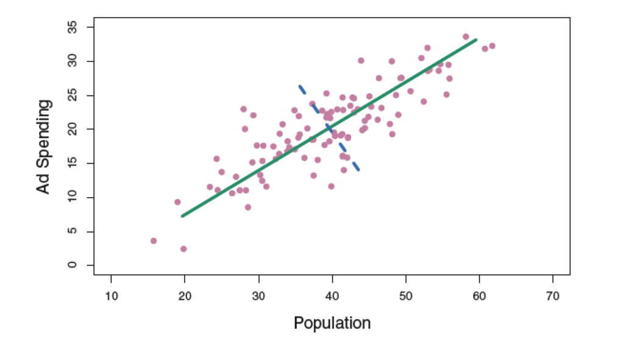

The first principal component is displayed graphically above; how can it be summarized mathematically? It is given by the formula

\begin{equation}\label{eq:pca_III} Z_{1}=0.839 \times(\mathrm{pop}-\overline{\mathrm{pop}})+0.544 \times(\mathrm{ad}-\overline{\mathrm{ad}}) \end{equation}

Here $\phi_{11}=0.839$ and $\phi_{21}=0.544$ are the principal component loadings, which define the direction referred to above.

In (\ref{eq:pca_III}), $\overline{\mathrm{pop}})$ indicates the mean of all $\mathrm{pop}$ values in this data set, and $\overline{\mathrm{ad}}$ indicates the mean of all advertising spending.

Basic idea: out of every possible linear combination of $\mathrm{pop}$ and $\mathrm{ad}$ such that $\phi_{11}^{2}+\phi_{21}^{2}=1$ this particular linear combination yields the highest variance: i.e. this is the linear combination for which $\operatorname{Var}\left(\phi_{11} \times(\mathrm{pop}-\overline{\mathrm{pop}})+\phi_{21} \times(\mathrm{ad}-\overline{\mathrm{ad}})\right)$ is maximized.

Necessary to consider only linear combinations of the form $\phi_{11}^{2}+\phi_{21}^{2}=1$, since otherwise we could increase $\phi_{11} \text { and } \phi_{21}$ arbitrarily in order to blow up the variance.

In (\ref{eq:pca_III}), the two loadings are both positive and have similar size, and so $Z_1$ is almost an average of the two variables.

Since $n = 100$, pop and ad are vectors of length $100$, and so is $Z_1$ in (\ref{eq:pca_III}). For instance,

\begin{equation} z_{i 1}=0.839 \times\left(\mathrm{pop}_{i}-\overline{\mathrm{pop}}\right)+0.544 \times\left(\mathrm{ad}_{i}-\overline{\mathrm{ad}}\right) \end{equation}

The values of $z_{11}, \dots, z_{n 1}$ are known as the principal component scores, and can be seen in the right-hand panel of the figure below:

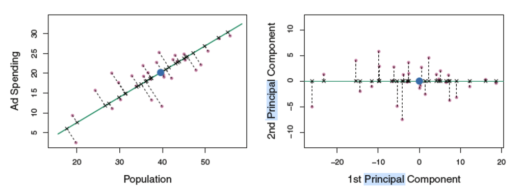

We can think of the values of the principal component $Z_1$ as single number summaries of the joint $\mathrm{pop}$ and $\mathrm{ad}$ budgets for each location. For example: if $z_{i 1}=0.839 \times\left(\text { pop }_{i}-\overline{\mathrm{pop}}\right)+0.544 \times\left(\mathrm{ad}_{i}-\overline{\mathrm{ad}}\right)<0$

This indicates a city with below-average population size and below average ad spending (and vice versa).

But: How well can a single number represent both pop and ad?

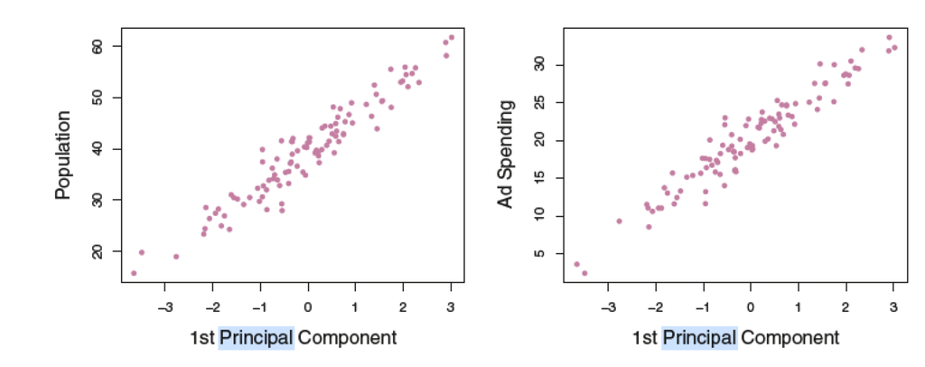

In general, we can construct up to $p$ distinct principal components.

In this example: the second principal component $Z_{2}$ is a linear combination of the variables that is uncorrelated with $Z_{1}$ and has largest variance subject to this constraint.

The second principal orthogonal component is given by the formula

$$Z_{2}=0.544 \times(\mathrm{pop}-\overline{\mathrm{pop}})-0.839 \times(\mathrm{ad}-\overline{\mathrm{ad}})$$

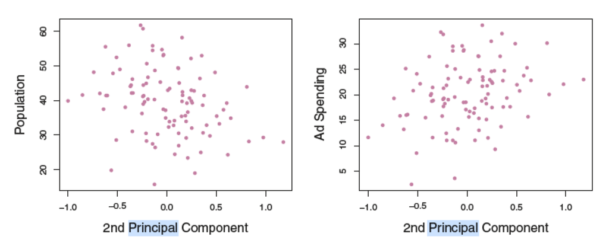

With two-dimensional data, we can construct at most two principal components.

However, if we had other predictors, such as population age, income level, education, and so forth, then additional components could be constructed. They would successively maximize variance, subject to the constraint of being uncorrelated with the preceding components.

**Example: PCA**

In the following example we will go through the steps of deriving the principal components in a simulated example using a slightly different technique:

```r
#####Data###############
x1<-c(2.5,0.5,2.2,1.9,3.1,2.3,2,1,1.5,1.1)
x2<-c(2.4,0.7,2.9,2.2,3.0,2.7,1.6,1.1,1.6,0.9)
```

1. 0.69

2. -1.31

3. 0.39

4. 0.0899999999999999

5. 1.29

6. 0.49

7. 0.19

8. -0.81

9. -0.31

10. -0.71

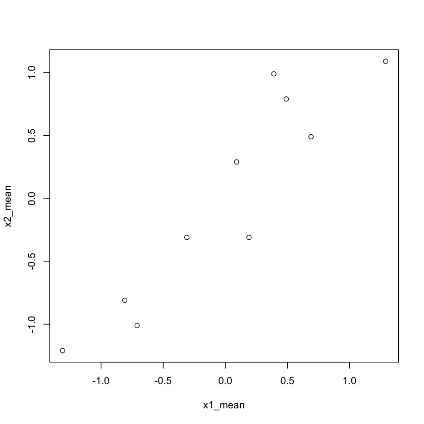

```r
####Demean both X's
x1_mean<-x1-mean(x1)
x2_mean<-x2-mean(x2)
###Any relationship?
plot(x1_mean,x2_mean)
x1_mean
```

```r
X=cbind(x1_mean,x2_mean)
X
```

A matrix: 10 × 2 of type dbl

| x1_mean | x2_mean |
| --- | --- |
| 0.69 | 0.49 |
| -1.31 | -1.21 |
| 0.39 | 0.99 |
| 0.09 | 0.29 |
| 1.29 | 1.09 |
| 0.49 | 0.79 |
| 0.19 | -0.31 |
| -0.81 | -0.81 |
| -0.31 | -0.31 |
| -0.71 | -1.01 |

```r
#####Covariance matrix###
cov.X=cov(X)
cov.X
```

A matrix: 2 × 2 of type dbl

|  | x1_mean | x2_mean |
| --- | --- | --- |
| x1_mean | 0.6165556 | 0.6154444 |
| x2_mean | 0.6154444 | 0.7165556 |

```r
###Calculate the eigenvalues and eigenvectors####
eigen_vectors<-eigen((cov.X))$vectors
eigen_values<-eigen((cov.X) )$values
eigen_vectors
eigen_values
```

A matrix: 2 × 2 of type dbl

| 0.6778734 | -0.7351787 |
| --- | --- |
| 0.7351787 | 0.6778734 |

1. 1.28402771217278

2. 0.0490833989383273

1

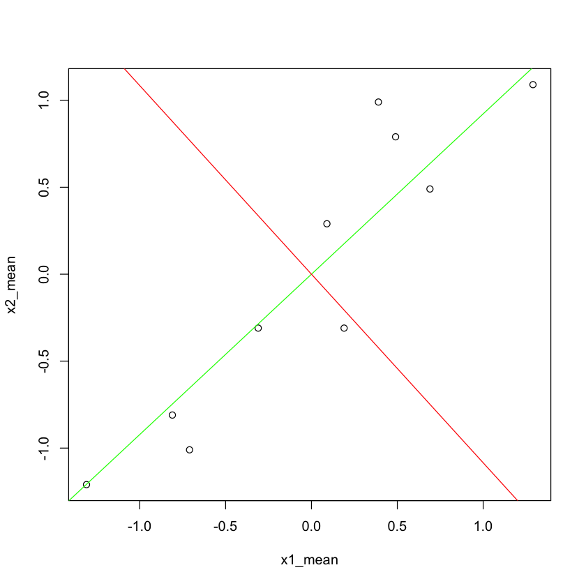

```r
#####Eigenvalues correctly scaled?
sqrt(eigen_vectors[1,1]^2 +eigen_vectors[2,1]^2)
######The slope is the first value divided by the second value########
plot(x1_mean,x2_mean)
abline(a=0,b=(eigen_vectors[1,1] /eigen_vectors[2,1]),col="green")
abline(a=0,b=(eigen_vectors[1,2] /eigen_vectors[2,2]),col="red")
```

Final Data $=$ RowFeatureVector $\times$ RowDataAdjust

```r
fin.data<-feat.vector_II%*%t(X)
```

[output not shown]

```r
fin.data
```

[output not shown]

## Principal components regression (PCR):

(1) constructing $M$ principal components, $Z_1, . . ., Z_M$, and (2) using these components as the predictors in a linear regression model that is fit using least squares.

**Key idea**: often a small number of principal components suffice to explain most of the variability in the data,**as well as** the relationship with the response.

In other words: we assume that the **directions** in which $X_1, . . .,X_p$ show the most variation are the directions that are associated with $Y$.

While this assumption is not guaranteed to be true, it often turns out to be a reasonable enough approximation to give good results.

If the assumption underlying PCR holds, then fitting a least squares model to $Z_1, . . ., Z_M$ will lead to better results than fitting a least squares model to $X_1, . . .,X_p$, since most or all of the information in the data that relates to the response is contained in $Z_1, . . ., Z_M$ and by estimating only $M \ll p$ coefficients we can mitigate overfitting.

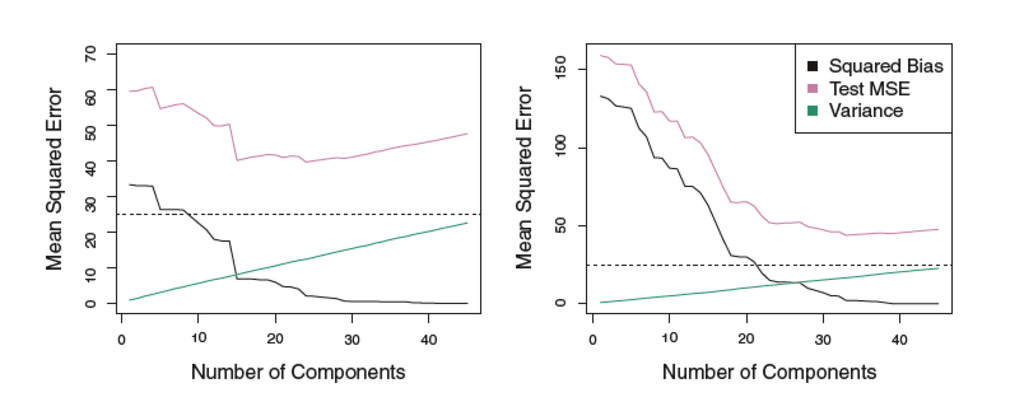

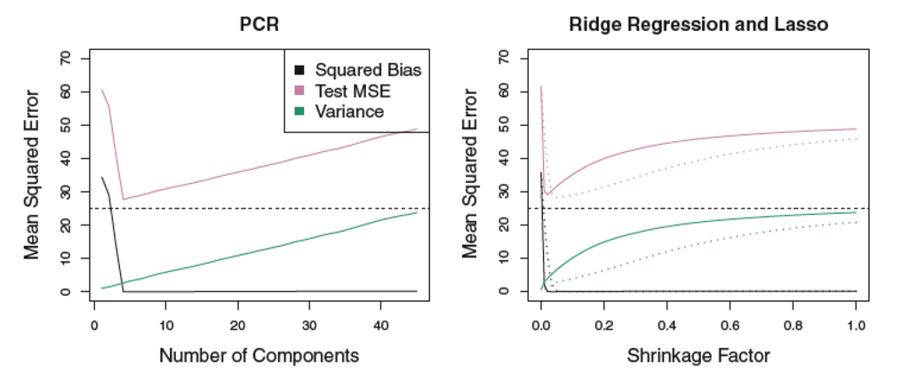

**To summarize:**

- performing PCR with an appropriate choice of $M$ can result in substantial improvement over least squares
- in this example, shrinkage works as well/ better (ridge/lasso)
- PCR performs relatively worse when many PC's are needed to model the response
- PCR does well when the first few principal components are sufficient to capture most of the variation in the predictors as well as the relationship with the response.
- But: even though PCR provides a simple way to perform regression using $M < p$ predictors, it is **not** a feature selection method.

Because: each of the $M$ principal components used in the regression is a linear combination of all $p$ of the original features.

For instance

\begin{equation}\label{eq:pca_III} Z_{1}=0.839 \times(\mathrm{pop}-\overline{\mathrm{pop}})+0.544 \times(\mathrm{ad}-\overline{\mathrm{ad}}) \end{equation}

$Z_1$: linear combination of both $\mathrm{pop}$ and $\mathrm{ad}$.

Therefore: PCR often performs quite well in many practical settings, it does not result in the development of a model that relies upon a small set of the original features.

In this sense: PCR is more closely related to ridge regression than to the lasso.

**Practicalities:**

- Number of principal components, $M$, typically chosen by cross-validation.
- Standardize predictors prior to generating the principal components.
- Might not be necessary if predictors are measured in the same units.

## Partial Least Squares

PCR: identifying linear combinations, or directions, that best represent the predictors $X_{1}, \ldots, X_{p}$.

Response does not supervise the identification of the principal components.

Consequently, PCR suffers from a drawback: there is no guarantee that the directions that best explain the **predictors** will also be the best directions to use for predicting the **response**.

In contrast: PLS is a dimension reduction method, that

- identifies squares a new set of features $Z_{1}, \dots, Z_{M}$ that are linear combinations of the original features
- fits a linear model via least squares using these M new features.

But: unlike PCR, PLS identifies new features in a supervised way.

After standardizing p predictors, PLS computes the first direction $Z_1$ by setting each $\phi_{j 1}$ in $$Z_{m}=\sum_{j=1}^{p} \phi_{j m} X_{j}$$ equal to the coefficient from the simple linear regression of Y onto $X_j$ . One can show that this coefficient is proportional to the correlation between Y and $X_j$.

Hence, in computing $Z_{1}=\sum_{j=1}^{p} \phi_{j 1} X_{j}$ PLS places the highest weight on the variables that are most strongly related to the response.

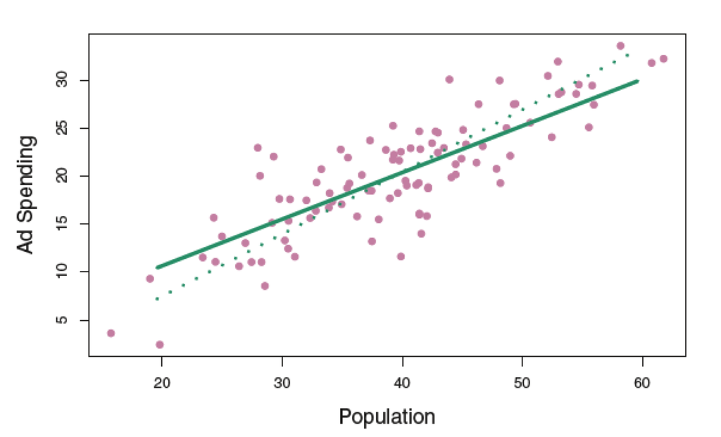

*The first PLS direction (solid line) and first PCR direction (dotted line) are shown.*

From figure above:

PLS choses a direction that has less change in the $\mathrm{ad}$ dimension per unit change in the $\mathrm{pop}$ dimension, relative to PCA.

This suggests: $\mathrm{pop}$ more highly correlated with the response than $\mathrm{ad}$.

To identify the second PLS direction: (1) first adjust each of the variables for $Z_1$, (2) regress each variable on $Z_1$ and taking residuals: can be interpreted as the remaining information that has not been explained by the first PLS direction. (3) then compute $Z_2$ using this orthogonalized data in exactly the same fashion as $Z_1$ was computed based on the original data. (4) Repeat this procedure $M$ times for PLS components $Z_1, . . ., Z_M$.

Finally: fit a linear model to predict Y using $Z_1, . . . , Z_M $ (using ls).

**Practicalities:**

- How to choose $M$: $M$ tuning parameter, typically chosen by cross-validation.
- We generally standardize the predictors and response before performing PLS.
- In practice: often performs no better than ridge regression or PCR, because: while the supervised dimension reduction of PLS can reduce bias, has potential to increase variance: overall benefit of PLS relative to PCR is a wash.

## High Dimensions

Data sets containing more features than observations are often referred to as high-dimensional.

Classical approaches such as least squares: not appropriate in this setting.

Many of the issues that arise in the analysis of high-dimensional data were discussed earlier, since they apply also when $n>p$:

With two observations: regardless of the values of those observations, the regression line will fit the data exactly $\rightarrow$ leads to overfitting.

This implies: the worse the ratio of $n$ to $p$:

- the more the need for an independent test set.
- the less informative the adjusted $R^2$ as a measure of goodness of fit is.